# Latihan 1 — Model Regresi Deret Waktu dengan Peubah Lag

STA1341 Metode Peramalan Deret Waktu — Market Share vs Price

Rizky Arif Wicaksono (M0401241054)

04 September 2026

# 1 Soal

> Misalkan terdapat set data pangsa pasar selama 20 periode dari suatu produk pasta gigi. Lakukan pemodelan *distributed lag* dari pangsa pasar (Y) terhadap harga (X). Temukan model terbaik!

Alur pengerjaan mengikuti tahapan praktikum: **impor data → bagi train/test → bangun beberapa model (Koyck, DLM, ARDL) → cari lag/orde optimum untuk tiap model → forecast pada data test → bandingkan akurasi via MAPE → pilih model terbaik**.

# 2 Impor Data

```r
Period      <- 1:20
MarketShare <- c(3.63, 4.20, 3.33, 4.54, 2.89, 4.87, 4.90, 5.29, 6.18, 7.20,
                  7.25, 6.09, 6.80, 8.65, 8.43, 8.29, 7.18, 7.90, 8.45, 8.23)
Price       <- c(0.97, 0.95, 0.99, 0.91, 0.98, 0.90, 0.89, 0.86, 0.85, 0.82,
                  0.79, 0.83, 0.81, 0.77, 0.76, 0.80, 0.83, 0.79, 0.76, 0.78)

data1 <- data.frame(Period, MarketShare, Price)
str(data1)
```

```
## 'data.frame':    20 obs. of  3 variables:
##  $ Period     : int  1 2 3 4 5 6 7 8 9 10 ...
##  $ MarketShare: num  3.63 4.2 3.33 4.54 2.89 4.87 4.9 5.29 6.18 7.2 ...
##  $ Price      : num  0.97 0.95 0.99 0.91 0.98 0.9 0.89 0.86 0.85 0.82 ...
```

```r
data1
```

| Period | MarketShare | Price |
| --- | --- | --- |
| 1 | 3.63 | 0.97 |
| 2 | 4.20 | 0.95 |
| 3 | 3.33 | 0.99 |
| 4 | 4.54 | 0.91 |
| 5 | 2.89 | 0.98 |
| 6 | 4.87 | 0.90 |
| 7 | 4.90 | 0.89 |
| 8 | 5.29 | 0.86 |
| 9 | 6.18 | 0.85 |
| 10 | 7.20 | 0.82 |

[output cut: 10 more lines]

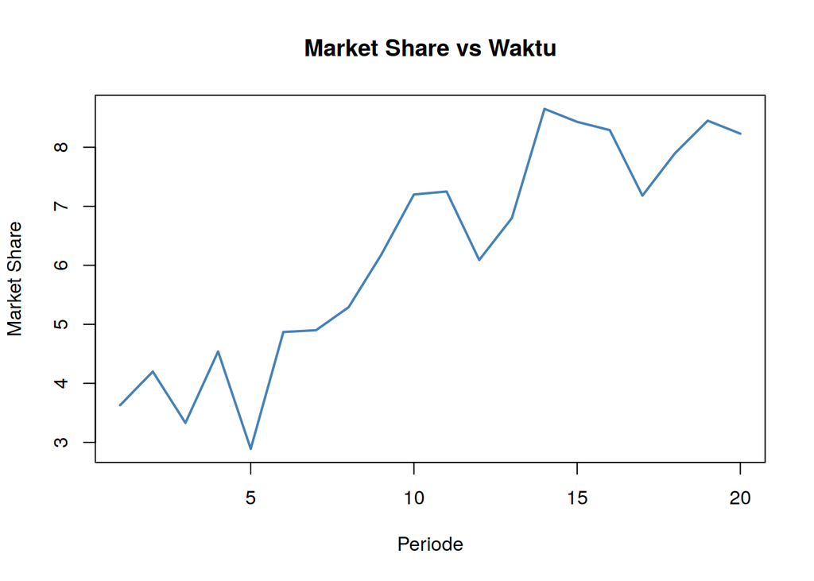

```r
plot(data1$Period, data1$MarketShare, type = "l", col = "steelblue", lwd = 2,
     xlab = "Periode", ylab = "Market Share", main = "Market Share vs Waktu")
```

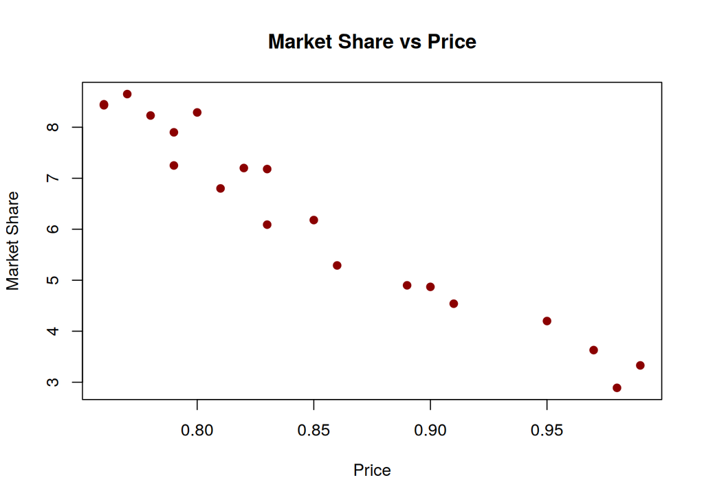

```r
plot(data1$Price, data1$MarketShare, pch = 19, col = "darkred",
     xlab = "Price", ylab = "Market Share", main = "Market Share vs Price")
```

Market share cenderung naik ketika price turun — hubungan negatif, sesuai teori ekonomi.

# 3 Pembagian Data (Train/Test)

Data dibagi 75:25 — 15 periode pertama untuk *training*, 5 periode terakhir untuk *testing* (menguji akurasi peramalan).

```r
train <- data1[1:15, ]
test  <- data1[16:20, ]
train.ts <- ts(train)
test.ts  <- ts(test)
data.ts  <- ts(data1)
```

- **Distributed lag model**: Y dipengaruhi oleh lag dari X ($X_{t-1}, X_{t-2}, \dots$)
- **Autoregressive model**: Y dipengaruhi oleh lag dirinya sendiri ($Y_{t-1}, \dots$) dan X sekarang

# 4 Model Koyck

```r
model.koyck <- koyckDlm(x = train$Price, y = train$MarketShare)
summary(model.koyck)
```

```
##
## Call:
## "Y ~ (Intercept) + Y.1 + X.t"
##
## Residuals:
##     Min      1Q  Median      3Q     Max
## -0.9997 -0.3171  0.0652  0.2586  1.1063
##
## Coefficients:
##             Estimate Std. Error t value Pr(>|t|)
## (Intercept)  15.4328    14.7611   1.046    0.318
## Y.1           0.3651     0.5152   0.709    0.493
## X.t         -13.4703    13.8869  -0.970    0.353
##
## Residual standard error: 0.599 on 11 degrees of freedom
## Multiple R-Squared: 0.9037,  Adjusted R-squared: 0.8861
## Wald test: 37.92 on 2 and 11 DF,  p-value: 1.16e-05
##
## Diagnostic tests:
## NULL
##
##                             alpha      beta       phi
## Geometric coefficients:  24.30938 -13.47028 0.3651498
```

```r
AIC(model.koyck); BIC(model.koyck)
```

```
## [1] 30.00231
```

```
## [1] 32.55853
```

```r
fore.koyck <- forecast(model = model.koyck, x = test$Price, h = 5)
fore.koyck
```

```
## $forecasts
## [1] 7.734805 7.076847 7.375405 7.888531 7.806494
##
## $call
## forecast.koyckDlm(model = model.koyck, x = test$Price, h = 5)
##
## attr(,"class")
## [1] "forecast.koyckDlm" "dLagM"
```

```r
mape.koyck <- MAPE(fore.koyck$forecasts, test$MarketShare)
mape.koyck
```

```
## [1] 0.05312954
```

```r
GoF(model.koyck)
```

|  | n | MAE | MPE | MAPE | sMAPE | MASE | MSE | MRAE | GMRAE |
| --- | --- | --- | --- | --- | --- | --- | --- | --- | --- |
| model.koyck | 14 | 0.4215632 | -0.01898878 | 0.08448088 | 0.08112884 | 0.4555545 | 0.2818772 | 1.457091 | 0.5463437 |

# 5 Regression with Distributed Lag (DLM)

## 5.1 Model dasar (q = 2)

```r
model.dlm <- dlm(formula = MarketShare ~ Price, data = train, q = 2)
summary(model.dlm)
```

```
##
## Call:
## lm(formula = as.formula(model.formula), data = design)
##
## Residuals:
##      Min       1Q   Median       3Q      Max
## -0.55526 -0.24858 -0.08971  0.20176  0.65633
##
## Coefficients:
##              Estimate Std. Error t value Pr(>|t|)
## (Intercept)  26.29549    1.69541  15.510 8.44e-08 ***
## Price.t     -24.13651    4.05335  -5.955 0.000214 ***
## Price.1      -0.00163    3.20631  -0.001 0.999606
## Price.2       0.34290    4.21417   0.081 0.936929
## ---
## Signif. codes:  0 '***' 0.001 '**' 0.01 '*' 0.05 '.' 0.1 ' ' 1
##
## Residual standard error: 0.4366 on 9 degrees of freedom
## Multiple R-squared:  0.9553, Adjusted R-squared:  0.9404
## F-statistic: 64.06 on 3 and 9 DF,  p-value: 2.151e-06
##
## AIC and BIC values for the model:
##        AIC     BIC
## 1 20.56206 23.3868
```

```r
fore.dlm <- forecast(model = model.dlm, x = test$Price, h = 5)
mape.dlm <- MAPE(fore.dlm$forecasts, test$MarketShare)
mape.dlm
```

```
## [1] 0.0705934
```

## 5.2 Lag Optimum

Karena datanya kecil (n = 20), pencarian dibatasi hingga q maksimum = 4 agar derajat bebas model tetap memadai.

```r
opt.dlm <- finiteDLMauto(formula = MarketShare ~ Price, data = data.frame(train),
                          q.min = 1, q.max = 4, model.type = "dlm",
                          error.type = "AIC", trace = TRUE)
opt.dlm
```

|  | q - k | MASE | AIC | BIC | GMRAE | MBRAE | R.Adj.Sq | Ljung-Box |
| --- | --- | --- | --- | --- | --- | --- | --- | --- |
| 3 | 3 | 0.27946 | 14.41990 | 17.32934 | 0.49694 | -0.34334 | 0.95685 | 0.8783956 |
| 4 | 4 | 0.29388 | 16.21356 | 18.99882 | 0.48458 | -0.05971 | 0.94508 | 0.6800769 |
| 1 | 1 | 0.35387 | 19.92429 | 22.48052 | 0.47815 | 1.13162 | 0.94457 | 0.3274301 |
| 2 | 2 | 0.32363 | 20.56206 | 23.38680 | 0.35152 | -0.40855 | 0.94035 | 0.6881871 |

```r
q.opt <- as.numeric(rownames(opt.dlm)[which.min(opt.dlm$AIC)])
cat("Lag optimum (AIC minimum): q =", q.opt, "\n")
```

```
## Lag optimum (AIC minimum): q = 3
```

```r
model.dlm2 <- dlm(formula = MarketShare ~ Price, data = train, q = q.opt)
summary(model.dlm2)
```

```
##
## Call:
## lm(formula = as.formula(model.formula), data = design)
##
## Residuals:
##      Min       1Q   Median       3Q      Max
## -0.35052 -0.24953  0.02349  0.19872  0.45187
##
## Coefficients:
##             Estimate Std. Error t value Pr(>|t|)
## (Intercept)   27.975      1.502  18.620  3.2e-07 ***
## Price.t      -27.521      3.935  -6.993 0.000213 ***
## Price.1        3.765      3.328   1.131 0.295228
## Price.2        2.805      3.518   0.797 0.451514
## Price.3       -4.800      3.486  -1.377 0.210928
## ---
## Signif. codes:  0 '***' 0.001 '**' 0.01 '*' 0.05 '.' 0.1 ' ' 1
##
## Residual standard error: 0.3504 on 7 degrees of freedom
## Multiple R-squared:  0.9725, Adjusted R-squared:  0.9569
## F-statistic: 61.99 on 4 and 7 DF,  p-value: 1.511e-05
##
## AIC and BIC values for the model:
##       AIC      BIC
## 1 14.4199 17.32934
```

```r
fore.dlm2 <- forecast(model = model.dlm2, x = test$Price, h = 5)
mape.dlm2 <- MAPE(fore.dlm2$forecasts, test$MarketShare)
mape.dlm2
```

```
## [1] 0.06395514
```

# 6 Model Autoregressive Distributed Lag (ARDL)

## 6.1 Model dasar (p = 1, q = 1)

```r
model.ardl <- ardlDlm(formula = MarketShare ~ Price, data = train, p = 1, q = 1)
summary(model.ardl)
```

```
##
## Time series regression with "ts" data:
## Start = 2, End = 15
##
## Call:
## dynlm(formula = as.formula(model.text), data = data)
##
## Residuals:
##      Min       1Q   Median       3Q      Max
## -0.50247 -0.30360 -0.05952  0.31335  0.74004
##
## Coefficients:
##               Estimate Std. Error t value Pr(>|t|)
## (Intercept)    18.1366     7.7391   2.344   0.0411 *
## Price.t       -23.5593     2.8404  -8.294 8.57e-06 ***
## Price.1         7.2280     7.2307   1.000   0.3411
## MarketShare.1   0.3028     0.3013   1.005   0.3386
## ---
## Signif. codes:  0 '***' 0.001 '**' 0.01 '*' 0.05 '.' 0.1 ' ' 1
##
## Residual standard error: 0.4177 on 10 degrees of freedom
## Multiple R-squared:  0.9574, Adjusted R-squared:  0.9446
## F-statistic: 74.91 on 3 and 10 DF,  p-value: 3.731e-07
```

```r
fore.ardl <- forecast(model = model.ardl, x = test$Price, h = 5)
mape.ardl <- MAPE(fore.ardl$forecasts, test$MarketShare)
mape.ardl
```

```
## [1] 0.0665442
```

## 6.2 Orde Optimum

Pencarian juga dibatasi (`max.p = 3`, `max.q = 3`) mengingat sampel yang kecil.

```r
opt.ardl <- ardlBoundOrders(data = data.frame(data1), ic = "AIC",
                             formula = MarketShare ~ Price, max.p = 3, max.q = 3)
opt.ardl
```

```
## $p
##   Price
## 1     2
##
## $q
## [1] 1
##
## $Stat.table
##          q = 1    q = 2    q = 3
## p = 1 26.44322 25.58593 27.90404
## p = 2 25.28483 27.28056 29.39566
## p = 3 29.66500 29.66500 29.54627
##
## $min.Stat
## [1] 25.28483
```

```r
p.opt <- as.numeric(opt.ardl$p["Price"])
q.opt.ardl <- opt.ardl$q
cat("Orde optimum (AIC minimum): p =", p.opt, ", q =", q.opt.ardl, "\n")
```

```
## Orde optimum (AIC minimum): p = 2 , q = 1
```

```r
model.ardl2 <- ardlDlm(formula = MarketShare ~ Price, data = train, p = p.opt, q = q.opt.ardl)
summary(model.ardl2)
```

```
##
## Time series regression with "ts" data:
## Start = 3, End = 15
##
## Call:
## dynlm(formula = as.formula(model.text), data = data)
##
## Residuals:
##      Min       1Q   Median       3Q      Max
## -0.48071 -0.21973 -0.05231  0.24589  0.72035
##
## Coefficients:
##               Estimate Std. Error t value Pr(>|t|)
## (Intercept)    19.8812     8.6380   2.302 0.050344 .
## Price.t       -23.5296     4.2291  -5.564 0.000532 ***
## Price.1         5.8131     8.3445   0.697 0.505759
## Price.2        -0.3281     4.4072  -0.074 0.942475
## MarketShare.1   0.2544     0.3356   0.758 0.470161
## ---
## Signif. codes:  0 '***' 0.001 '**' 0.01 '*' 0.05 '.' 0.1 ' ' 1
##
## Residual standard error: 0.4473 on 8 degrees of freedom
## Multiple R-squared:  0.9583, Adjusted R-squared:  0.9374
## F-statistic: 45.92 on 4 and 8 DF,  p-value: 1.467e-05
```

```r
fore.ardl2 <- forecast(model = model.ardl2, x = test$Price, h = 5)
mape.ardl2 <- MAPE(fore.ardl2$forecasts, test$MarketShare)
mape.ardl2
```

```
## [1] 0.06265417
```

# 7 Pemodelan Setara dengan `dynlm` (untuk Uji Diagnostik)

Fungsi `koyckDlm`/`dlm`/`ardlDlm` tidak menyediakan uji diagnostik langsung, sehingga digunakan `dynlm` dengan spesifikasi yang setara untuk menjalankan uji asumsi klasik dan *encompassing test*.

```r
cons_lm1 <- dynlm(MarketShare ~ Price + L(Price), data = train.ts)               # DLM q=1
cons_lm2 <- dynlm(MarketShare ~ Price + L(MarketShare), data = train.ts)         # ARDL p=1,q=0 (Koyck-like)
cons_lm3 <- dynlm(MarketShare ~ Price + L(Price) + L(MarketShare), data = train.ts) # ARDL p=1,q=1
cons_lm4 <- dynlm(MarketShare ~ Price + L(Price) + L(Price, 2), data = train.ts)    # DLM q=2

cat("SSE cons_lm1 (DLM q=1)  :", deviance(cons_lm1), "\n")
```

```
## SSE cons_lm1 (DLM q=1)  : 1.921133
```

```r
cat("SSE cons_lm2 (ARDL 1,0) :", deviance(cons_lm2), "\n")
```

```
## SSE cons_lm2 (ARDL 1,0) : 1.919254
```

```r
cat("SSE cons_lm3 (ARDL 1,1) :", deviance(cons_lm3), "\n")
```

```
## SSE cons_lm3 (ARDL 1,1) : 1.744895
```

```r
cat("SSE cons_lm4 (DLM q=2)  :", deviance(cons_lm4), "\n")
```

```
## SSE cons_lm4 (DLM q=2)  : 1.715214
```

## 7.1 Encompassing Test

```r
encomptest(cons_lm1, cons_lm2)
```

|  | Res.Df | Df | F | Pr(>F) |
| --- | --- | --- | --- | --- |
| M1 vs. ME | 10 | -1 | 1.0100238 | 0.3385955 |
| M2 vs. ME | 10 | -1 | 0.9992511 | 0.3410657 |

Model 1 (DLM, `Price + L(Price)`) sudah cukup memadai — menambahkan lag $Y$ (Model 2) tidak memberikan peningkatan signifikan (p > 0.05 pada baris M1 vs ME), begitu pula sebaliknya.

## 7.2 Uji Autokorelasi (Durbin-Watson)

```r
dwtest(cons_lm1); dwtest(cons_lm2); dwtest(cons_lm3); dwtest(cons_lm4)
```

```
##
##  Durbin-Watson test
##
## data:  cons_lm1
## DW = 1.4113, p-value = 0.09999
## alternative hypothesis: true autocorrelation is greater than 0
```

```
##
##  Durbin-Watson test
##
## data:  cons_lm2
## DW = 1.4291, p-value = 0.08808
## alternative hypothesis: true autocorrelation is greater than 0
```

```
##
##  Durbin-Watson test
##
## data:  cons_lm3
## DW = 1.7892, p-value = 0.2647
## alternative hypothesis: true autocorrelation is greater than 0
```

```
##
##  Durbin-Watson test
##
## data:  cons_lm4
## DW = 1.5683, p-value = 0.1739
## alternative hypothesis: true autocorrelation is greater than 0
```

## 7.3 Uji Heteroskedastisitas (Breusch-Pagan)

```r
bptest(cons_lm1); bptest(cons_lm2); bptest(cons_lm3); bptest(cons_lm4)
```

```
##
##  studentized Breusch-Pagan test
##
## data:  cons_lm1
## BP = 0.47133, df = 2, p-value = 0.79
```

```
##
##  studentized Breusch-Pagan test
##
## data:  cons_lm2
## BP = 0.70938, df = 2, p-value = 0.7014
```

```
##
##  studentized Breusch-Pagan test
##
## data:  cons_lm3
## BP = 1.4806, df = 3, p-value = 0.6868
```

```
##
##  studentized Breusch-Pagan test
##
## data:  cons_lm4
## BP = 0.56825, df = 3, p-value = 0.9037
```

## 7.4 Uji Normalitas (Shapiro-Wilk)

```r
shapiro.test(residuals(cons_lm1))
```

```
##
##  Shapiro-Wilk normality test
##
## data:  residuals(cons_lm1)
## W = 0.94345, p-value = 0.4642
```

```r
shapiro.test(residuals(cons_lm2))
```

```
##
##  Shapiro-Wilk normality test
##
## data:  residuals(cons_lm2)
## W = 0.95012, p-value = 0.5626
```

```r
shapiro.test(residuals(cons_lm3))
```

```
##
##  Shapiro-Wilk normality test
##
## data:  residuals(cons_lm3)
## W = 0.94674, p-value = 0.5113
```

```r
shapiro.test(residuals(cons_lm4))
```

```
##
##  Shapiro-Wilk normality test
##
## data:  residuals(cons_lm4)
## W = 0.95071, p-value = 0.6091
```

Semua model (`cons_lm1` s.d. `cons_lm4`) lolos ketiga uji asumsi klasik pada taraf nyata 5% (tidak ada autokorelasi, homoskedastis, residual menyebar normal).

# 8 Perbandingan Model

```r
akurasi <- data.frame(
  Model = c("Koyck",
            "DLM (q=2)",
            paste0("DLM (q=", q.opt, ", optimum)"),
            "ARDL (1,1)",
            paste0("ARDL (", p.opt, ",", q.opt.ardl, ", optimum)")),
  AIC = c(AIC(model.koyck), AIC(model.dlm), AIC(model.dlm2), AIC(model.ardl), AIC(model.ardl2)),
  BIC = c(BIC(model.koyck), BIC(model.dlm), BIC(model.dlm2), BIC(model.ardl), BIC(model.ardl2)),
  MAPE_test = round(c(mape.koyck, mape.dlm, mape.dlm2, mape.ardl, mape.ardl2), 4)
)
```

```
## [1] 30.00231
## [1] 20.56206
## [1] 14.4199
## [1] 20.5772
## [1] 21.66028
## [1] 32.55853
## [1] 23.3868
## [1] 17.32934
## [1] 23.77248
## [1] 25.04998
```

```r
akurasi[order(akurasi$MAPE_test), ]
```

|  | Model | AIC | BIC | MAPE_test |
| --- | --- | --- | --- | --- |
| 1 | Koyck | 30.00231 | 32.55853 | 0.0531 |
| 5 | ARDL (2,1, optimum) | 21.66028 | 25.04998 | 0.0627 |
| 3 | DLM (q=3, optimum) | 14.41990 | 17.32934 | 0.0640 |
| 4 | ARDL (1,1) | 20.57720 | 23.77248 | 0.0665 |
| 2 | DLM (q=2) | 20.56206 | 23.38680 | 0.0706 |

Berdasarkan **MAPE data test** (kriteria akurasi peramalan luar-sampel), model **Koyck** memiliki nilai MAPE terkecil (0.0531), sehingga dipilih sebagai **model terbaik** untuk memprediksi market share berdasarkan price — meskipun model DLM dengan lag optimum memberikan AIC/BIC (kecocokan dalam-sampel) yang lebih kecil. Hal ini wajar: AIC/BIC mengukur kecocokan pada data training, sedangkan MAPE mengukur akurasi sesungguhnya pada data baru (test) — dan untuk tujuan peramalan, akurasi luar-sampel lebih diutamakan.

## 8.1 Plot Perbandingan Forecast vs Aktual

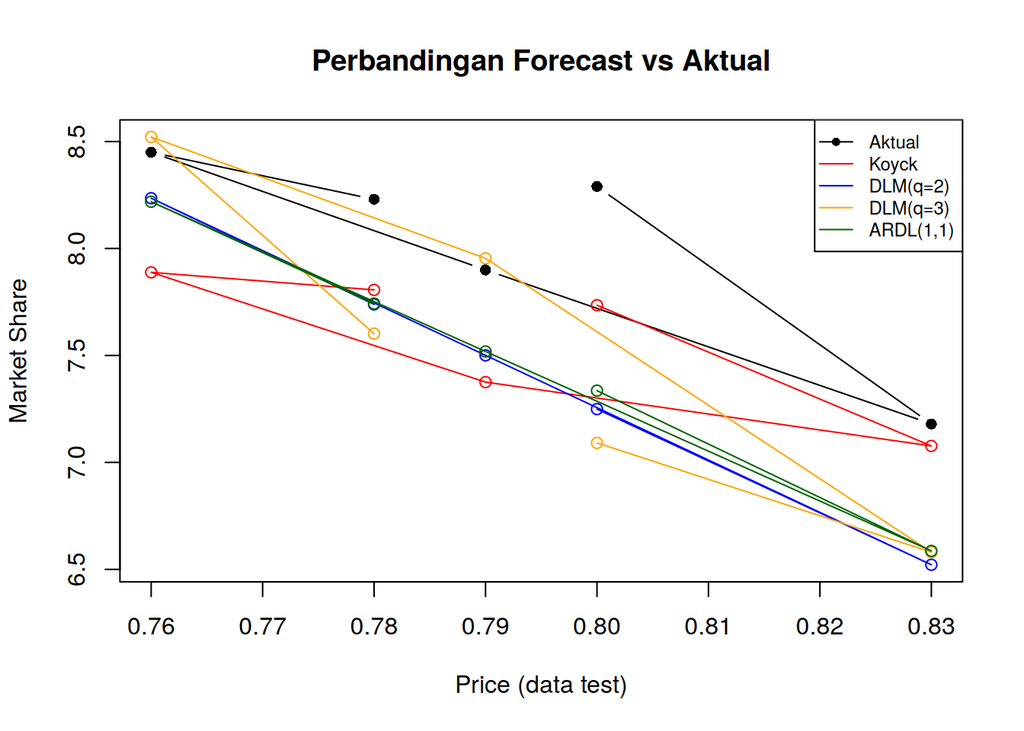

```r
plot(test$Price, test$MarketShare, type = "b", col = "black", pch = 16,
     ylim = range(c(test$MarketShare, fore.koyck$forecasts, fore.dlm$forecasts,
                     fore.dlm2$forecasts, fore.ardl$forecasts)),
     xlab = "Price (data test)", ylab = "Market Share",
     main = "Perbandingan Forecast vs Aktual")
points(test$Price, fore.koyck$forecasts, col = "red"); lines(test$Price, fore.koyck$forecasts, col = "red")
points(test$Price, fore.dlm$forecasts, col = "blue"); lines(test$Price, fore.dlm$forecasts, col = "blue")
points(test$Price, fore.dlm2$forecasts, col = "orange"); lines(test$Price, fore.dlm2$forecasts, col = "orange")
points(test$Price, fore.ardl$forecasts, col = "darkgreen"); lines(test$Price, fore.ardl$forecasts, col = "darkgreen")
legend("topright", c("Aktual", "Koyck", "DLM(q=2)", paste0("DLM(q=",q.opt,")"), "ARDL(1,1)"),
       lty = 1, pch = c(16, NA, NA, NA, NA),
       col = c("black", "red", "blue", "orange", "darkgreen"), cex = 0.75)
```

# 9 Model Terbaik & Interpretasi

```r
koyck_coefs <- coef(model.koyck)
```

[output not shown]

```r
koyck_coefs
```

```
## (Intercept)         Y.1         X.t
##  15.4328158   0.3651498 -13.4702790
```

```r
alpha_hat <- koyck_coefs["(Intercept)"]
phi_hat   <- koyck_coefs["Y.1"]
beta_hat  <- koyck_coefs["X.t"]
LR_mult1  <- beta_hat / (1 - phi_hat)
c(alpha = alpha_hat, phi = phi_hat, beta0 = beta_hat, LR_multiplier = LR_mult1)
```

```
## alpha.(Intercept)           phi.Y.1         beta0.X.t LR_multiplier.X.t
##        15.4328158         0.3651498       -13.4702790       -21.2180429
```

**Model Koyck terbaik:**

$$\hat{Y}_t = 15.433 -13.47\,X_t + 0.365\,Y_{t-1}$$

**Interpretasi:**

- **Dampak jangka pendek** ($\beta_0$ = -13.47): kenaikan harga 1 unit langsung menurunkan market share sebesar 13.47 poin pada periode yang sama.
- **Koefisien $Y_{t-1}$** ($\phi$ = 0.365) menunjukkan proporsi efek market share periode lalu yang masih terbawa ke periode ini (kelembaman/inersia pasar).
- **Dampak jangka panjang (*long-run multiplier*)**:
  $$\frac{\beta_0}{1-\phi} = \frac{-13.47}{1-0.365} = -21.218$$
  Jika kenaikan harga 1 unit dipertahankan permanen, total penurunan market share dalam jangka panjang adalah 21.218 poin.
- Model ini juga memberikan **MAPE data test terkecil** (5.31%) di antara seluruh model yang dicoba (Koyck, DLM, ARDL), menandakan performa peramalan luar-sampel yang paling baik.